## Example 3 - Analyzing data when the excitation is unknown, with some inter- and intraindividual noise

Similarly to the example 2, we will generate data so that the analysis can fit a decreasing exponential, as is the case when there is no excitation, when it is unknown, or when it is constant over time.

```r
#Simulating data with these hypothesis
mydatab3 <- generate.panel.remi(nind = 6,
                          dampingtime = 10,
                          amplitude = -1,
                          nexc = 1,
                          duration = 50,
                          deltatf = 1,
                          tmax = 50,
                          minspacing = 0,
                          internoise = 0.4,
                          intranoise = 0.2)
```

Note that decreasing exponentials can be easily generated through the simulation function by setting a negative amplitude of the excitation pulse and “extending” the pulse throughout the time period.

```r
#Analysing
resultb3 <- remi(data = mydatab3,
                 id = "id",
                 time = "time",
                 signal = "dampedsignal",
                 embedding = 5)
```

```
#> [1] "Status: panel data"
#> [1] "Status: Unknown excitation. Linear mixed-effect model calculated."
#> [1] "Status: Linear mixed-effect model had no errors."
#> [1] "Status: Unknown excitation. Calculation of estimated signal through exponential fit."
```

Note that the `input` parameter has been omitted when calling the function.

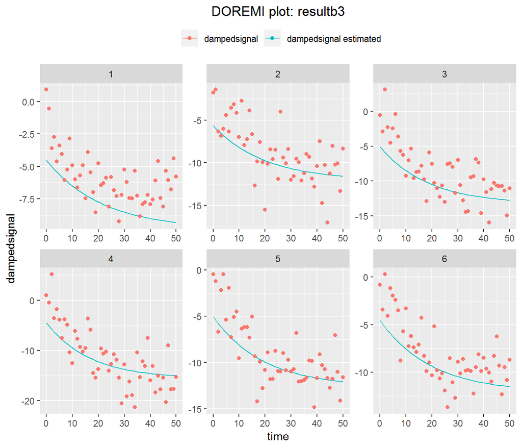

```r
#Plotting
plot(resultb3)
```

## Example 4 - Analyzing data from a single individual

In this case, we can reuse the signals of the example 2 for a single individual

```r
#Creating the data table
mydatab4 <- data.frame(time = timt1,
                 excitation = et1,
                 signalcol = y1)
```

Note that the `id` parameter has been omitted when calling the function.

```r
#Analyzing
resultb4 <- remi(data = mydatab4,
                 input = "excitation",
                 time ="time",
                 signal = "signalcol",
                 embedding = 5)
```

```
#> [1] "Status: Time series data"
#> [1] "Status: One or several excitations. Linear regression calculated"
#> [1] "Status: Linear mixed-effect model had no errors"
#> [1] "Status: One or several excitations. Calculation of estimated signal through convolution"
```

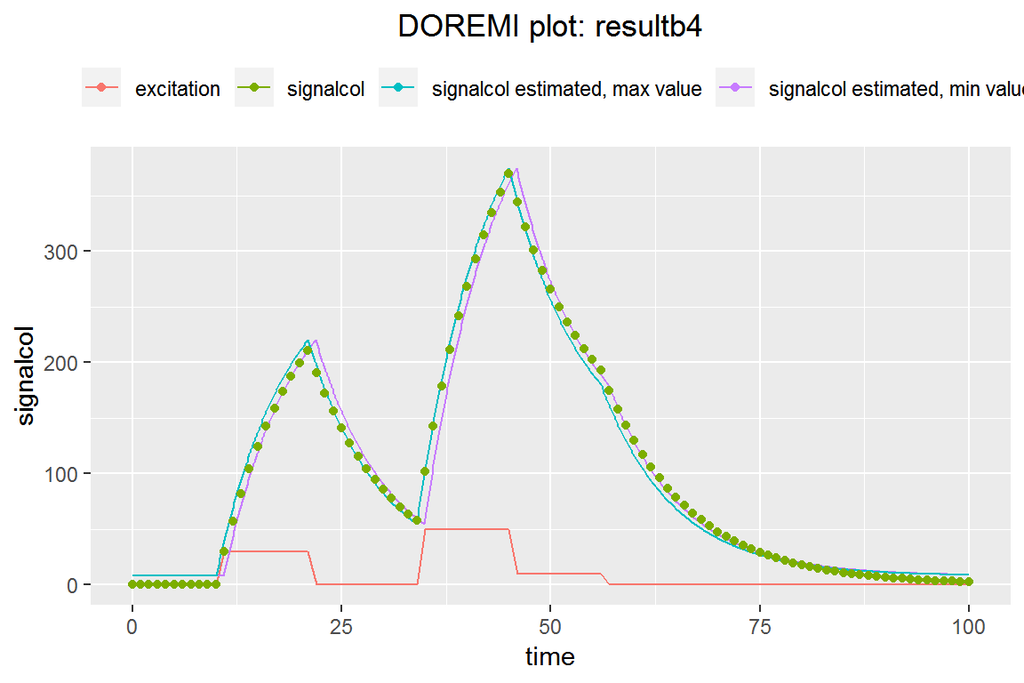

```r
#Plotting
plot(resultb4)
```

## Example 5 - Analyzing data when there are some missing points in the signal

When simulating signals with missing measurements, we examine how the analysis function still manages to retrieve an accurate fit:

```r
mydatab5 <- generate.panel.remi(nind = 4,
                          dampingtime = 10,
                          amplitude = 1,
                          nexc = 3,
                          duration = 10,
                          deltatf = 0.5,
                          tmax = 100,
                          minspacing = 20,
                          internoise = 0.1,
                          intranoise = 0.2)

#Keeping one third of the rows selected randomly from the full data set
mydatab5rd <- mydatab5$fulldata[sample(nrow(mydatab5$fulldata), nrow(mydatab5$fulldata)/3), ]
mydatab5rd <- mydatab5rd[order(id,time)]
```

In the next plot we show the selection of random points made on the full data set (by accessing the list `$fulldata`of the doremidata object). The signal without noise has been represented in order to better see the selection of points made. However, the signal with noise will be used to carry out the analysis.

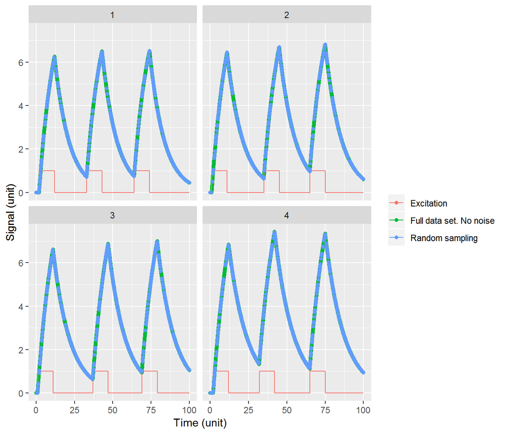

```r
ggplot2::ggplot( data = mydatab5$fulldata ) +
  ggplot2::geom_point(ggplot2::aes(time,dampedsignalraw, colour = "Full data set. No noise"))+
  ggplot2::geom_line(ggplot2::aes(time,excitation,colour = "Excitation"))+
  ggplot2::geom_point(data = mydatab5rd, ggplot2::aes(time,dampedsignalraw, colour = "Random sampling"))+
  ggplot2::facet_wrap(~id)+
  ggplot2::labs(x = "Time (unit)",
           y = "Signal (unit)",
           colour = "")
```

Then analyzing and visualizing the random points selection:

```r
resultb5 <- remi(data = mydatab5rd,
                 id = "id",
                 input = "excitation",
                 time ="time",
                 signal = "dampedsignal",
                 embedding = 5)
```

```
#> [1] "Status: panel data"
#> [1] "Status: One or several excitations. Linear mixed-effect model calculated."
#> [1] "Status: Linear mixed-effect model had no errors."
#> [1] "Status: One or several excitation terms. Calculation of estimated signal through convolution."
```

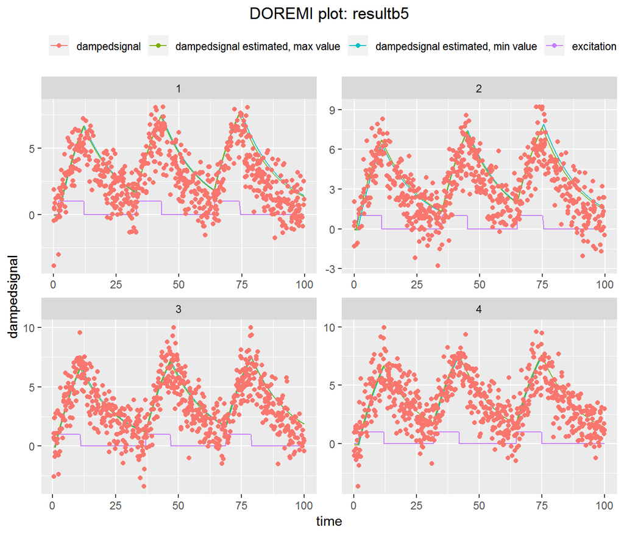

```r
plot(resultb5)
```

# C - Applications

## C1 - Measuring heart frequency during effort tests

Using the `cardio` dataset present in this package, we will apply the model to real heart frequency measurements. The data fields are described with detail in the pdf manual of the package, together with the source from which the data was obtained. In brief, the data is from 21 individuals carrying out an effort test on a cycle ergometer, and measuring heart rate. Participants pedal on a bicycle with increasing resistance. The resistance load is measured in watts, with higher load forcing the individual to greater effort. His/her heart frequency will then vary according to the effort supplied and the participant’s fitness. According to this, the `cardio` data includes, for each individual, the time since the beginning of the test (seconds), the bicycle load (Watts) and the heart rate (1/min).

```r
resultc1 <- remi(data = cardio,
                 id = "id",
                 input = "load",
                 time ="time",
                 signal = "hr",
                 embedding = 5)
```

```
#> [1] "Status: panel data"
#> [1] "Status: One or several excitations. Linear mixed-effect model calculated."
#> [1] "Status: Linear mixed-effect model had no errors."
#> [1] "Status: One or several excitation terms. Calculation of estimated signal through convolution."
```

Plotting analysis results for all 21 participants. Note that omitting the argument `id` would lead to only the first 6 participants being plotted by default.

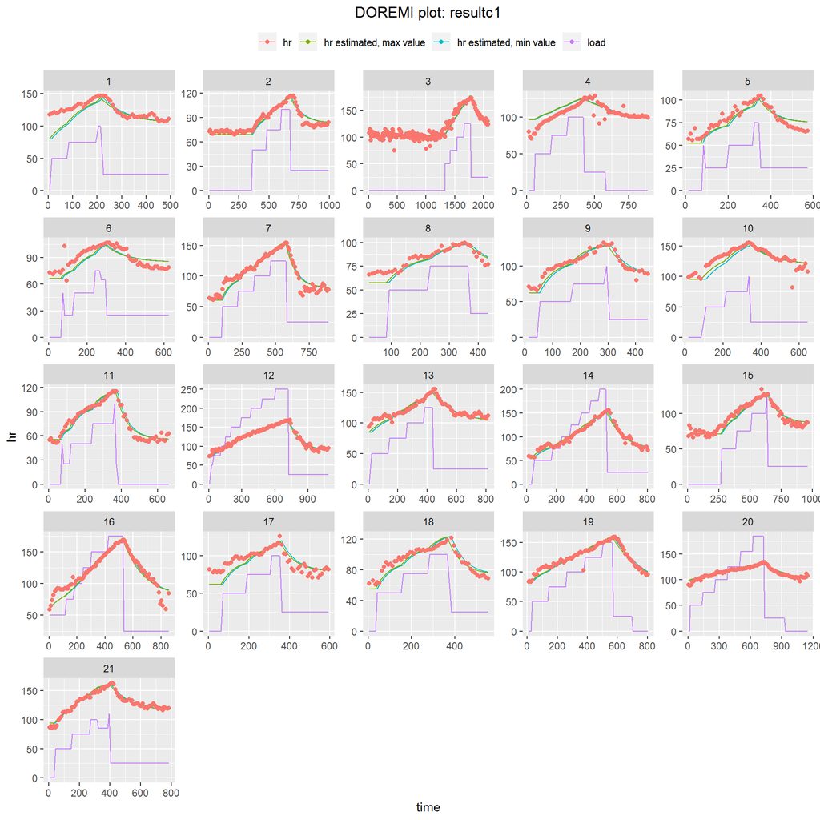

```r
plot(resultc1, id = 1:21)
```

As can be seen, the model reproduces quite well the variation of the heart rate, and can be used to fully characterize the heart rate dynamics with three simple parameters: the resting heart rate (the equilibrium value), the characteristic time of heart rate change (the damping time), and the increase of heart rate for a given effort (the excitation coefficient).

## C2 - Meaurements of response time of individuals when carrying out mental rotation tasks

Using the `rotation` dataset present in this package, we will apply the model to a case in which the excitation signal is not clearly defined. In brief, the data is from 17 individuals that carried out mental rotation tasks (identify if two figures, one of which is rotated, are the same or a mirror image) and the response time (in milliseconds) was measured [(Courvoisier et al., 2013)](https://doi.org/10.1016/j.yhbeh.2012.12.007). Each individual was measured every day for 60 days, though there can be missing data. To account for this, the time has been represented by the number of days since the beginning of the experiment (variable `days`). The signal is the mean response time (variable `meanRT`) over the ~200 stimuli done every day. The purpose of the study was to compare the performance between men and women.

```r
resultc2 <- remi(data = rotation,
                 id = "id",
                 time ="days",
                 signal = "meanRT",
                 embedding = 5)
```

```
#> [1] "Status: panel data"
#> [1] "Status: Unknown excitation. Linear mixed-effect model calculated."
#> [1] "Status: Linear mixed-effect model had no errors."
#> [1] "Status: Unknown excitation. Calculation of estimated signal through exponential fit."
```

Plotting analysis results:

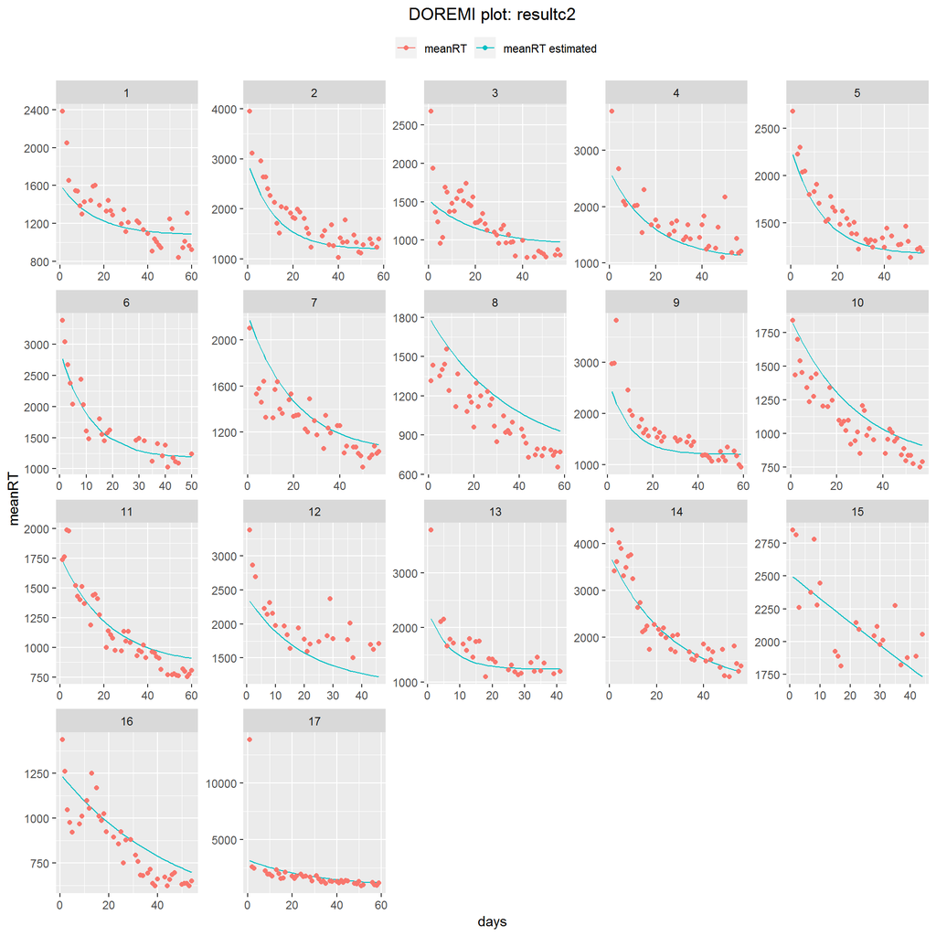

```r
plot(resultc2, id = 1:17)
```

As can be seen, the decreasing exponential fit shows that response time is reduced throughout the trials and thus the days, indicating that the individual has learned and can execute the task faster by the end of the tests. Furthermore, the damping time for men’s mean response time was shorter than for women, as it can be seen in the box plot below, built with the information in `$resultid` and adding the sex:

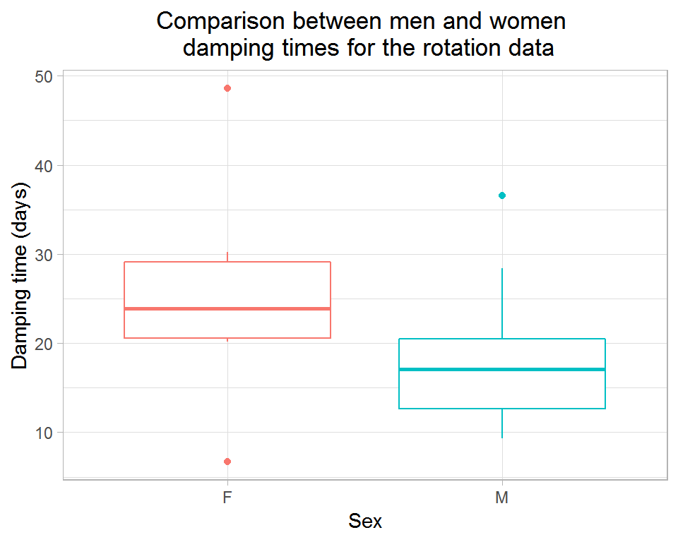

Which confirms the results of the study by [Courvoisier et al. (2013)](https://doi.org/10.1016/j.yhbeh.2012.12.007).

# D - Print, summary, plot and predict with doremi objects

As seen earlier, it is possible to print a doremi object by just calling the variable in which the doremi object is stored. It is also possible to print a summary of it by using the `summary` function available in R and to plot it directly using the `plot` function. In the same way, a S3 method for the `predict` function has been included to handle doremi objects. Thus, it is possible to carry out an analysis of a given signal and excitation and then use the analysis results to predict the signal that would have occurred if another different excitation had happened. Taking example 2 of section B, we select only the first individual, and the first part of the data to have a single excitation. We then use the results to carry out a prediction of the second signal to the second excitation. Finally, we will verify that the result of the predict function matches the second signal.

```r
#Input data
#Taking et1, et2, y1 and y2 from example b2
#Creating data frame with the pair e1,y1
mydatad1 <- data.frame(time = timt1, exc = et1, y1 = y1)

#Analysis
resultd1 <- remi(data = mydatad1,
                 input = "exc",
                 time = "time",
                 signal = "y1",
                 embedding = 5)
```

```
#> [1] "Status: Time series data"
#> [1] "Status: One or several excitations. Linear regression calculated"
#> [1] "Status: Linear mixed-effect model had no errors"
#> [1] "Status: One or several excitations. Calculation of estimated signal through convolution"
```

```r
#Creating data frame with et2 that will be supplied as new excitation for the predict function
mydatad1$exc <- et2

#Calling the predict function
predresultd1<- predict(resultd1,
                       newdata = mydatad1)
```

```
#> [1] "Predict status: time series"
```

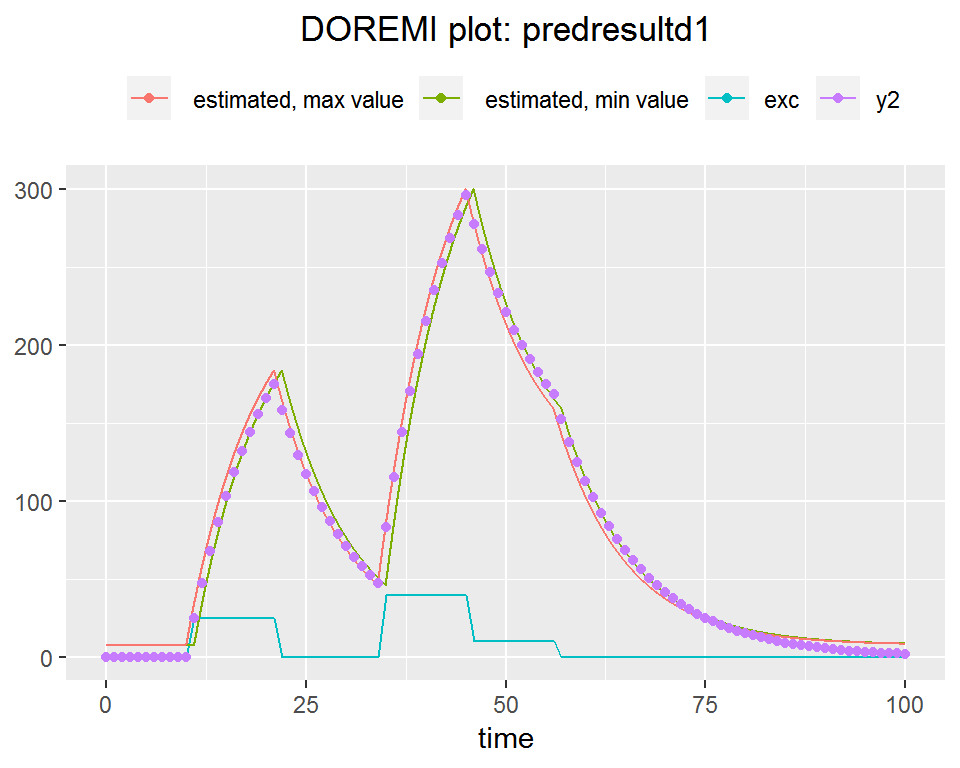

```r
#Comparing with calculated signal y2
q <- plot(predresultd1)
q + ggplot2::geom_point(ggplot2::aes(predresultd1$data$time, y2,colour = "y2"))
```